# Homework 6 Group _ Validation and Regularization

Trang Vu, Rebekah Stottlemyer, Karan Pillay

2/28/2020

## Problem 1 (20 points):

### 1. (10 points) Create a KNN classifier model to predict the pdc-80-flag using the following continuous features “total-los”,“num-op”,“num-er”,“num- ndc”,“pre-total-cost”, and “pre-CCI”. Use 10-fold cross validation to de- termine which value of K produces the most accurate result from the range k = 31 to 101 with a step size of 2.

```r
library(caret)
library(clusterSim)
library(class)
library(flexclust)
library(matlib)
```

```r
# Prepare the dataset
train_data= read.csv("healthcareTrain.csv")
test_data = read.csv("healthcareTest.csv")
dim(train_data)
```

```
## [1] 1378   96
```

```r
# Predict the pdc-8-flag using the following features
#total_los
#num_op
#num_er
#num_ndc
#pre_total_cost
#pre_CCI
library(class)
train_data1 <- train_data[,c("total_los","num_op","num_er","num_ndc","pre_total_cost","pre_CCI")]
test_data1 <- test_data[,c("total_los","num_op","num_er","num_ndc","pre_total_cost","pre_CCI")]

# since label of training data and testing data located in 94th column in the dataframes
# subset them to separated variables.
train_labels <- train_data[,94]
test_labels <- test_data[,94]
```

#### Data Normalization (Use the training parameters for normalization of test points)

```r
# Normarlize our continous data, using train_data1 as the parameter to normalize test_data1
library(caret)
normParam <- preProcess(train_data1, method = c("center","scale"))
norm.trainData1 <- predict(normParam, train_data1)
norm.testData1 <- predict(normParam, test_data1)
```

```r
# Make train and test labels become dataframe
train_labels <- as.data.frame(train_labels)
test_labels <- as.data.frame(test_labels)
```

#### Use 10-fold cross validation to determine which value of K produces the most accurate result from the range k = 31 to 101 with a step size of 2.

```r
# Split the dataset into K equal partitions (or "folds")
# So if k = 10 and dataset has 1378 observations
# Each of the 10 folds would have approximate 137.8 observations(1 small or less)
nrFolds <- 10

# Create a temporary dataset with traindata and train label.
# preparing for shuffle
shuff <-  norm.trainData1
shuff$labels <- train_data[,94]
```

```r
# Set seed to 123, shuffling the data
set.seed(123)
shuff <- shuff[sample(nrow(shuff)),]

# Now we subset train data and train label from the shuffled data
norm.trainData_shuff <- shuff[,c("total_los","num_op","num_er","num_ndc","pre_total_cost","pre_CCI")]
train_labels_shuff <- shuff[,c("labels")]
train_labels_shuff <- as.data.frame(train_labels_shuff)
```

```r
# generate array containing fold-number for each sample
#folds <- rep_len(1:nrFolds, nrow(norm.trainData_shuff))
folds <- cut(seq(1,nrow(shuff)),breaks = 10, labels = FALSE)
# Take a look at the first 500 of our folds
head(folds, n = 500)
```

```
##   [1] 1 1 1 1 1 1 1 1 1 1 1 1 1 1 1 1 1 1 1 1 1 1 1 1 1 1 1 1 1 1 1 1 1 1 1
##  [36] 1 1 1 1 1 1 1 1 1 1 1 1 1 1 1 1 1 1 1 1 1 1 1 1 1 1 1 1 1 1 1 1 1 1 1
##  [71] 1 1 1 1 1 1 1 1 1 1 1 1 1 1 1 1 1 1 1 1 1 1 1 1 1 1 1 1 1 1 1 1 1 1 1
## [106] 1 1 1 1 1 1 1 1 1 1 1 1 1 1 1 1 1 1 1 1 1 1 1 1 1 1 1 1 1 1 1 1 1 2 2
## [141] 2 2 2 2 2 2 2 2 2 2 2 2 2 2 2 2 2 2 2 2 2 2 2 2 2 2 2 2 2 2 2 2 2 2 2
## [176] 2 2 2 2 2 2 2 2 2 2 2 2 2 2 2 2 2 2 2 2 2 2 2 2 2 2 2 2 2 2 2 2 2 2 2
## [211] 2 2 2 2 2 2 2 2 2 2 2 2 2 2 2 2 2 2 2 2 2 2 2 2 2 2 2 2 2 2 2 2 2 2 2
## [246] 2 2 2 2 2 2 2 2 2 2 2 2 2 2 2 2 2 2 2 2 2 2 2 2 2 2 2 2 2 2 2 3 3 3 3
## [281] 3 3 3 3 3 3 3 3 3 3 3 3 3 3 3 3 3 3 3 3 3 3 3 3 3 3 3 3 3 3 3 3 3 3 3
## [316] 3 3 3 3 3 3 3 3 3 3 3 3 3 3 3 3 3 3 3 3 3 3 3 3 3 3 3 3 3 3 3 3 3 3 3
## [351] 3 3 3 3 3 3 3 3 3 3 3 3 3 3 3 3 3 3 3 3 3 3 3 3 3 3 3 3 3 3 3 3 3 3 3
## [386] 3 3 3 3 3 3 3 3 3 3 3 3 3 3 3 3 3 3 3 3 3 3 3 3 3 3 3 3 3 4 4 4 4 4 4
## [421] 4 4 4 4 4 4 4 4 4 4 4 4 4 4 4 4 4 4 4 4 4 4 4 4 4 4 4 4 4 4 4 4 4 4 4
## [456] 4 4 4 4 4 4 4 4 4 4 4 4 4 4 4 4 4 4 4 4 4 4 4 4 4 4 4 4 4 4 4 4 4 4 4
## [491] 4 4 4 4 4 4 4 4 4 4
```

#### Cross Validation Process.

```r
# actual cross validation
# Create a loop to repeat the process 10 times since we have 10 folds
# Each iteration we will choose one fold as a test set and the rest folds is training set.
# Alternatively, repeating the process until we use all the premaded fold for test set one by one for each loop.

testing_accuracy <- c()
for(m in 1:nrFolds) {
    # actual split of the data
    fold <- which(folds == m, arr.ind = TRUE)
    data.train <- norm.trainData_shuff[-fold,]
    train.labels1 <- train_labels_shuff[-fold,]
    data.test <- norm.trainData_shuff[fold,]
    test.labels1 <-train_labels_shuff[fold,]
   # train and test your model with data.train and data.test
   data_test_pred <- lapply(seq(31, 101, by=2) , function(i) knn(train = data.train, test = data.test, cl = train.labels1, k = i ))
   # compare the prediction to test labels
   confMatrix = lapply(1:36, function(x) mean((data_test_pred[[x]]) == test.labels1))

   # Get the accuracy rate for each k (from 31 to 101 step by 2) for each cross validation
   # Store in big list below
   # testing_accuracy will have 10 list, each list contains 36 accuracy rate results.

   testing_accuracy[[m]] <- confMatrix
}
```

```r
require(stats)
# Create a matrix from our testing_accuracy list
# with row representing k, column representing 10 times cross validation result.
k_accuracy_ave <- c()
a <- matrix(unlist(testing_accuracy),nrow = 36)
#a <- do.call(cbind,testing_accuracy)

# apply mean function with margin = 1 (row)
# calcuate the average of accuracy rates for each k in 10 cross validation.

k_accuracy_ave = apply(a,MARGIN = 1, FUN = mean)
k_accuracy_ave
```

```
##  [1] 0.6153496 0.6175341 0.6117423 0.6124564 0.6102877 0.5979636 0.6030149
##  [8] 0.5950333 0.5935946 0.5993917 0.5993970 0.5943246 0.5994023 0.6023061
## [15] 0.5993917 0.5972178 0.6008198 0.5979054 0.5957368 0.5906802 0.5942928
## [22] 0.5913890 0.5913943 0.5870306 0.5877446 0.5899238 0.5892045 0.5913784
## [29] 0.5928224 0.5978896 0.5978948 0.5920977 0.5928277 0.5921030 0.6008040
## [36] 0.6022638
```

```r
# Make a table with knames and its corresponding average accuracy rate
#k_accuracy_ave
knames = c(seq(31, 101, by=2))
accuracytable <- cbind(knames,k_accuracy_ave)
print("The mean accuracy rate for each k using 10-fold cross validation is  ")
```

```
## [1] "The mean accuracy rate for each k using 10-fold cross validation is  "
```

```r
accuracytable
```

```
##       knames k_accuracy_ave
##  [1,]     31      0.6153496
##  [2,]     33      0.6175341
##  [3,]     35      0.6117423
##  [4,]     37      0.6124564
##  [5,]     39      0.6102877
##  [6,]     41      0.5979636
##  [7,]     43      0.6030149
##  [8,]     45      0.5950333
##  [9,]     47      0.5935946
## [10,]     49      0.5993917
## [11,]     51      0.5993970
## [12,]     53      0.5943246
## [13,]     55      0.5994023
## [14,]     57      0.6023061
```

[output cut: 22 more lines]

```r
cat("Highest accuracy rate is",max(round(k_accuracy_ave,5)),"with k equals to ",33)
```

```
## Highest accuracy rate is 0.61753 with k equals to  33
```

*According to the table of accuracy results above, it is clear that using 10-fold cross validation, the value of K that produces the most accurate result is k = 33 with accuracy rate of 0.6175341.*

### 2. (5 points) Plot the accuracy rate from your 10-fold cross validation vs. K.

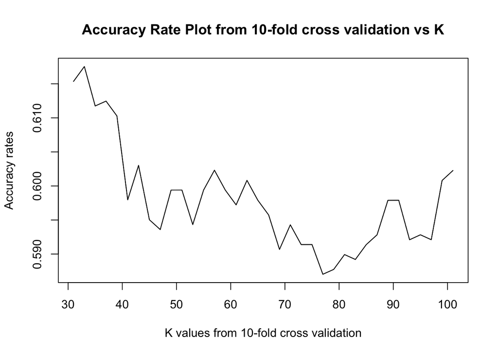

```r
plot(k_accuracy_ave, x = (seq(31, 101, by=2)), type = "l", lty = 1, main="Accuracy Rate Plot from 10-fold cross validation vs K",
  xlab="K values from 10-fold cross validation", ylab="Accuracy rates")
lines(k_accuracy_ave,x = (seq(31, 101, by=2)),type = "l", lty = 1)
```

### 3. (5 points) Use the best value of K to predict the pdc-80-flag for the test set. How does your validation error compare to test error?

```r
#Using built-in knn function on our original normalized training set and test
cl = train_labels[,1]
predict_test = knn(train = norm.trainData1, test = norm.testData1, cl , k = 33)
accuracy_test <- mean(as.data.frame(predict_test) == test_labels)
cat("Using built-in function, we have the accuracy rate with k = 33 is: ", round(accuracy_test,3),"\n")
```

```
## Using built-in function, we have the accuracy rate with k = 33 is:  0.613
```

```r
error_test <- 1 - accuracy_test
error_valiation <- 1 - max(k_accuracy_ave)
cat("Validation error is ", (round(error_valiation,5))*100, "%\n")
```

```
## Validation error is  38.247 %
```

```r
cat("Test error is ", (round(error_test,3))*100, "%")
```

```
## Test error is  38.7 %
```

```r
cat("\nCompare validation error to test error, the difference between validation and test error is ",round(abs(error_valiation - error_test),5)*100,"%")
```

```
##
## Compare validation error to test error, the difference between validation and test error is  0.416 %
```

*Using the best value of K = 33 to predict the pdc-80-flag for the test set, we got an accuracy rate of 61.3. The test error is 38.7% while the validation error is 38.2%. The difference is small and insignificant.The validation error is 0.416 % smaller than the test errors. This tells us that we did not under/over estimate the training/validation set and the error estimation. By using the 10-fold cross validation method we can mostly estimate what the test error will be.*

## Problem 2 (20 points):

### 1. (5 points) Generate 10,000 hypotheses for each version. Report the average hypothesis g ̄(x) in each case.

```r
# Generate 10000 hypothesis for each version
set.seed(123)
numSet = 2*10000
x = matrix(runif(numSet, min = -1, max = 1), nrow = 2)
#Target Function
f = sin(pi*x)
```

```r
library(MASS)
# unregularized model
# find slope and intercept by using ginv() function b=ginv(x)*y
gLine2 = sapply(1:(numSet/2), function(i) ginv(matrix(c(1,1,x[,i]), nrow=2))%*%f[,i])
gLineBar2 = apply(gLine2, MARGIN = 1, FUN = mean)
# Take mean, margin = 1 for rowmeans we have the gbar for unregularized linear model
print("The average hypothesis g_bar(x) of the unregularized model is: ")
```

```
## [1] "The average hypothesis g_bar(x) of the unregularized model is: "
```

```r
gLineBar2
```

```
## [1] -0.01556352  0.79778922
```

$y = x*0.7977892 - 0.01556352$

```r
library(matlib)
# Turn lamda into identical matrix
lamda <- matrix(c(0.1,0,0,0.1),nrow = 2)

# weight-decay regulized model
# apply regularization into the model with w = inv(t(X)*X + lamda)*t(X)*y

gLine2_reg = sapply(1:(numSet/2), function(i) (inv(t(matrix(c(1,1,x[,i]), nrow=2))%*%matrix(c(1,1,x[,i]), nrow=2) + lamda)) %*% t(matrix(c(1,1,x[,i]), nrow=2))%*% f[,i])

# Take mean, margin = 1 for rowmeans we have the gbar for regularized linear model
gLineBar2_reg = apply(gLine2_reg, MARGIN = 1, FUN = mean)
gLineBar2_reg
```

```
## [1] -0.005659488  0.636188789
```

```r
print("The average hypothesis g_bar(x) of the regularized model is: ")
```

```
## [1] "The average hypothesis g_bar(x) of the regularized model is: "
```

$y = x*0.636188789 - 0.005659488$

### 2. (5 points) Find and report bias2 for each model.

```r
# unregularized model
xVec = seq(-1, +1, by = 10^-4) # Create a vector x to find f(x) and subsequently the bias at every x.
fXvec = sin(pi*xVec)
# Finding bias for linear model
gLineBarXvec2 = xVec*(0.79778922) - 0.01556352
biasLine2 = mean((gLineBarXvec2 - fXvec)^2)
cat("Bias2 for unregularized linear model is", round(biasLine2,5))
```

```
## Bias2 for unregularized linear model is 0.20453
```

```r
# regularized model
gLineBarXvec2_reg = lapply(1:20001, function(i) (xVec[i]*(0.631) - 0.005))
gLineBarXvec2_reg = do.call(rbind,gLineBarXvec2_reg)
biasLine2_reg = mean((gLineBarXvec2_reg - fXvec)^2)
cat("Bias2 for regularized linear model is", round(biasLine2_reg,5))
```

```
## Bias2 for regularized linear model is 0.23105
```

### 3. (5 points) Find and report variance for each model

```r
# unregularized model
gLineXvec = matrix(c(rep(1,length(xVec)),xVec), ncol=2)%*%gLine2

# Below is the avg. g evaluted at each x
gLineBar_xVec = gLineBar2%*%matrix( c(rep(1,length(xVec)), xVec), byrow = TRUE,nrow=2)

varXvec2 <- lapply(1:10000,function(i) (gLineXvec[,i] - gLineBar_xVec[1,])**2)
varXvec2 <- do.call(cbind,varXvec2)
varXvec2 <- rowSums(varXvec2)/(10000 - 1)  # horizontal
finalvar <- mean(varXvec2)                 # vertical
cat("Variance for unregularized linear model is", round(finalvar,5))
```

```
## Variance for unregularized linear model is 1.64976
```

```r
# regulize model
gLineXvec_reg = matrix(c(rep(1,length(xVec)),xVec), ncol=2)%*%gLine2_reg

# Below is the avg. g evaluted at each x
gLineBar_xVec_reg =  gLineBar2_reg%*%matrix( c(rep(1,length(xVec)), xVec), byrow = TRUE,nrow=2)

varXvec02 <- lapply(1:10000,function(i) (gLineXvec_reg[,i] - gLineBar_xVec_reg[1,])**2)
varXvec02 <- do.call(cbind,varXvec02)
varXvec02 <- rowSums(varXvec02)/(10000 - 1)  # horizontal
finalvar2 <- mean(varXvec02)                 # vertical
cat("Variance for unregularized linear model is", round(finalvar2,5))
```

```
## Variance for unregularized linear model is 0.32708
```

### 4. (5 Points) For each case, plot g ̄(x) ± √var along with g ̄(x) and target function f(x) = sin(πx) . Which model will you choose? Why? Round your answers to 3 decimal places.

#### a. Model y = x*0.7977892 - 0.01556352

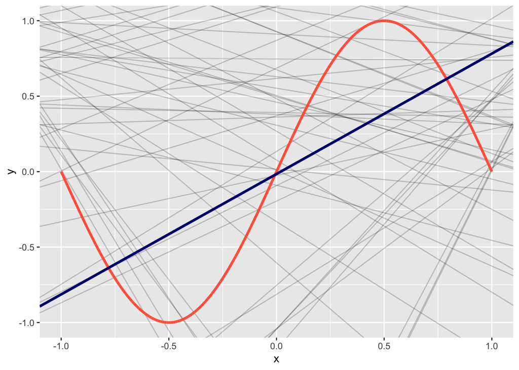

```r
ggplot(data = data.frame(x = xVec, y = sin(pi*xVec)), aes(x,y)) +
  geom_abline(data = data.frame(s = gLine2[1,1:100], i = gLine2[2,1:100]),
            aes(slope = s, intercept = i),
            alpha = 0.2) +
  geom_line(color = "tomato", size = 1.2) +
  geom_abline(slope = gLineBar2[2],
              intercept = gLineBar2[1],
              color = "navy",
              size = 1.2) +
  expand_limits(x = c(-.25, .25), y = c(-.25, .25))
```

#### b. Unregularized linear regression model, plot g ̄(x) ± √var along with g ̄(x) and target function f(x)

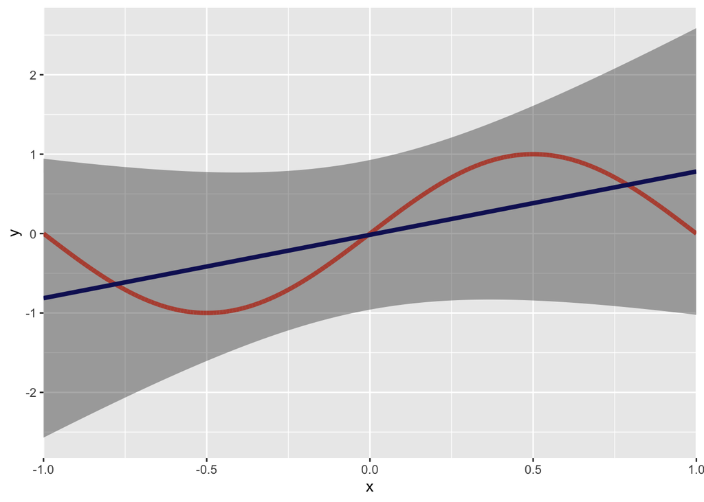

```r
ggplot(data = data.frame(x = xVec, y = sin(pi*xVec)), aes(x,y)) +
  geom_line(color = "tomato", size = 1.5) +
  geom_abline(aes(slope = gLineBar2[2], intercept = gLineBar2[1]),
              color = "navy", size = 1.5) +
  geom_ribbon(aes(ymin = gLineBar_xVec[1,] - sqrt(varXvec2), ymax = gLineBar_xVec[1,] + sqrt(varXvec2)),
              alpha = 0.4) +
  scale_x_continuous(expand = c(0,0))
```

#### c. Regularized linear regression model, plot g ̄(x) ± √var along with g ̄(x) and target function f(x)

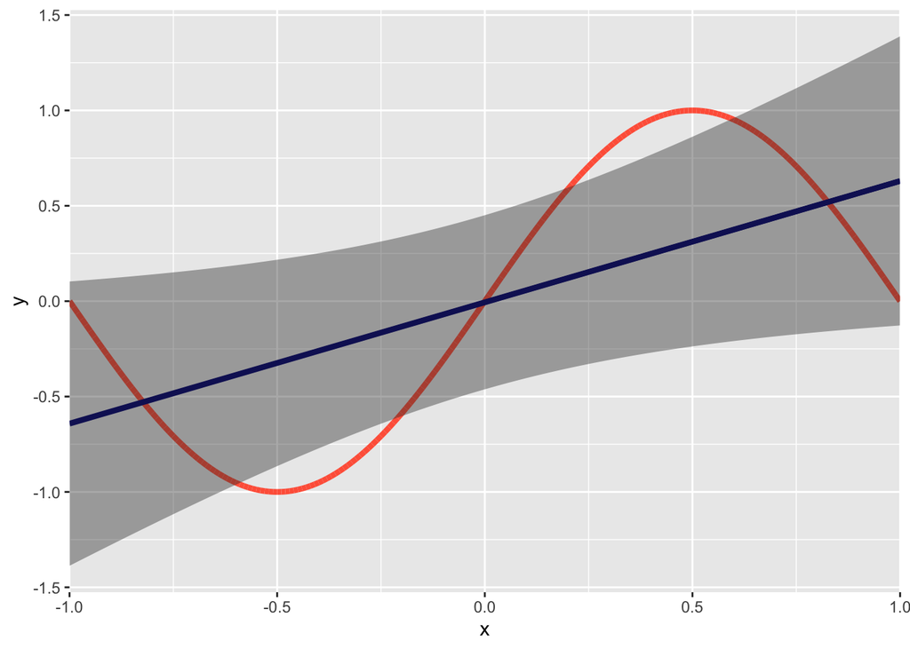

```r
ggplot(data = data.frame(x = xVec, y = sin(pi*xVec)), aes(x,y)) +
  geom_line(color = "tomato", size = 1.5) +
  geom_abline(aes(slope = gLineBar2_reg[2], intercept = gLineBar2_reg[1]),
              color = "navy", size = 1.5) +
  geom_ribbon(aes(ymin = gLineBar_xVec_reg[1,] - sqrt(varXvec02), ymax = gLineBar_xVec_reg[1,] + sqrt(varXvec02)),
              alpha = 0.4) +
  scale_x_continuous(expand = c(0,0))
```

#### d. Which model will you choose? Why? Round your answers to 3 decimal places.

```r
# Let's calculate the error of unregularized and regularized model by the summation between variance with bias square
error_unreg = finalvar + biasLine2
error_reg = finalvar2 + biasLine2_reg
cat("Error of unregularized linear regression model is ",round(error_unreg,3),"\n")
```

```
## Error of unregularized linear regression model is  1.854
```

```r
cat("Error of regularized linear regression model is ",round(error_reg,3))
```

```
## Error of regularized linear regression model is  0.558
```

```r
# Create a dataset to store the result.
table <- as.data.frame (matrix(c(round(biasLine2,3),round(biasLine2_reg,3),round(finalvar,3),round(finalvar2,3),round(error_unreg,3),round(error_reg,3)),nrow =3,byrow = TRUE))
colnames(table) = c("unregularized LM","regularized LM")
rownames(table) = c("Bias square", "Variance","Error")
table
```

```
##             unregularized LM regularized LM
## Bias square            0.205          0.231
## Variance               1.650          0.327
## Error                  1.854          0.558
```